# L'expressivité d'un modèle relative à la série de Fourier

Dans notre premier modèle quantique mono-qubit, nous avons montré l'équivalence entre notre modèle de la série de Fourier et notre modèle quantique mono-qubit dans leur implémentation en NumPy.

Notre dernier modèle, qui interagit avec notre simulation quantique, présente cette même caractéristique. Nous n'allons pas montrer leur équivalence pour prouver une même égalité à un niveau simplement plus complexe.

Mais on peut en tirer une chose très importante. Par équivalence, notre modèle quantique générique dispose des mêmes propriétés que le modèle quantique qui infère avec une série de Fourier quantique.

Donc, on en déduit que notre modèle quantique dispose aussi de coefficients de Fourier.

Ces coefficients sont comme des moteurs pour notre modèle quantique. Jusqu'à présent, ils ne sont pas suggérés dans nos calculs. Mais ils sont sous-jacents.

Ces coefficients sont essentiels pour notre modèle quantique. Ils sont un vrai outil d'optimisation.

# Le calcules des coefficents de Fourrier

Les calculs des coefficients de Fourier se font de la même manière que le modèle approxime de manière quantique ou qu'il approxime de manière classique des fonctions qui sont composées de fonctions sinusoïdales.

Pour calculer les coefficients de Fourier, cela revient à décomposer la fonction approximée par le modèle en une somme de fonctions sinusoïdales.

Ce qui revient à faire une série de Fourier rapide sur la valeur d'approximation du modèle, dans notre cas, on utilisera la méthode FFT de NumPy.

Voilà l'implémentation de la fonction d'approximation par rapport à notre modèle de référence :

```python
import numpy as np
import matplotlib.pyplot as plt
from source.quantum_model import *

def coefficients_fourier(model, linespace=np.linspace(-6, 6), num_points=1024):

    # On définit la variable x sur l'espace de recherche donné
    x = linespace

    # On évalue le modèle sur cet espace pour obtenir l'approximation de la série de Fourier
    y = model.forward(x)

    # On applique la transformation de Fourier rapide (FFT) et calcule les fréquences correspondantes
    coeffs = np.fft.fft(y) / num_points
    freqs = np.fft.fftfreq(num_points, d=(x[1] - x[0]))

    # On retourne les fréquences et les coefficients de Fourier
    return freqs, coeffs
```

Pour le calcul des coefficients de Fourier, il est hyper important d'avoir une visualisation de ce que l'on fait. Voici une implémentation qui prend en charge ce calcul de coefficients et qui les affiche pour les visualiser, et qui, à terme, va nous servir d'outil.

```python
def display_coefficients_fourier(model, num_display, linspace=np.linspace(-6, 6, 1024), title=""):
    # On calcule les coefficients et les fréquences
    freqs, coeffs = coefficients_fourier(model, linspace)

    # On prépare l'affichage
    fig, axes = plt.subplots(1, num_display, figsize=(2 * num_display, 4), sharex=True, sharey=True)

    for col in range(num_display):
        ax = axes[col]
        c = coeffs[col]

        # Choix de couleur pour montrer l'importance du coefficient dans l'inférence quantique
        color = 'gray' if round(c.real , 1) == 0.0 and round(c.imag , 1) == 0.0 else 'blue'

        # Affichage du coefficient
        ax.scatter(c.real, c.imag, s=50, marker='o', facecolors='none', edgecolors=color)
        ax.set_xlim(-1, 1)
        ax.set_ylim(-1, 1)
        ax.set_aspect('equal')
        ax.set_xticks(np.linspace(-1, 1, 5))
        ax.set_yticks(np.linspace(-1, 1, 5))
        ax.grid(True, linestyle="--", alpha=0.6)
        ax.set_title(f"C{col}", fontsize=12)

        # Ajout d'une annotation affichant de manière permanente la fréquence correspondante
        freq_display = freqs[col]
        ax.text(0.05, 0.9, f"f = {freq_display:.2f}", transform=ax.transAxes,
                fontsize=10, color='green',
                bbox=dict(facecolor='white', alpha=0.5, edgecolor='none'))

    # Ajout du titre du schéma si nécessaire
    if title:
        fig.suptitle(title, fontsize=16)

    plt.tight_layout()
    plt.show()
```

Nous allons essayer d'exposer les coeficients de notre premier modèle mono-qubit avec une seul couche.

```
--- Circuit ---
|0⟩—[W(0j, 0j, 0j)]—[S(0j)]—[W(0j, 0j, 0j)]—> M
```

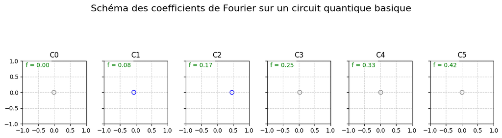

```python
num_layer = 1

gamma = 1

circuit_0 = "W(v,v,v)-S(x)-W(v,v,v)"

Qm = quantum_model(circuit_0, gamma)


display_coefficients_fourier(Qm, 6, np.linspace(-6, 6, 1024), "Schéma des coefficients de Fourier sur un circuit quantique basique")
```

On remarque que certains coefficients sont illuminés et d'autres non.

Les coefficients sont les coefficients qui servent à représenter la capacité d'expression du modèle quantique.

On remarque que seuls les C1 et C2 sont allumés. Et on peut faire un lien avec notre démonstration de la série de Fourier quantique, dans laquelle on a montré ces termes C0 et C2. C0 dans notre cas exprime une certaine constance nulle pour le modèle.

Cette visualisation montre effectivement cette similarité du modèle de série quantique avec l'expression de série quantique avec un layer.

*NB : C3 n'est pas strictement égal à 0, il est sufisamment proche de 0 pour être négligée dans l'expressivité de ce modèle quantique*

Ces coefficients se situent dans l'espace complexe et servent à décrire l'expressivité du circuit quantique.

Maintenant ajoutons un gestionnaire de poids

```
--- Circuit ---
|0⟩—[W(0j, 0j, 0j)]—[W(0j, 0j, 0j)]—[S(0j)]—[W(0j, 0j, 0j)]—> M
```

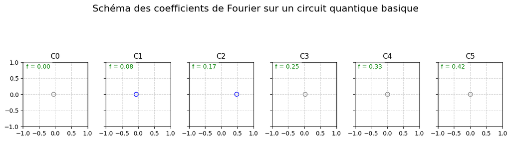

```python
num_layer = 2

gamma = 1

circuit_1 = "W(v,v,v)-W(v,v,v)-S(x)-W(v,v,v)"


Qm1 = quantum_model(circuit_1, gamma)


display_coefficients_fourier(Qm1, 6, np.linspace(-6, 6, 1024), "Schéma des coefficients de Fourier sur un circuit quantique basique")
```

On constate que l'augmentation des coefficients n'améliore pas l'expressivité du modèle.

Essayons juste avec une couche X en plus, sans les nouveaux poids.

```
--- Circuit ---
|0⟩—[W(0j, 0j, 0j)]—[S(0j)]—[S(0j)]—[W(0j, 0j, 0j)]—> M
```

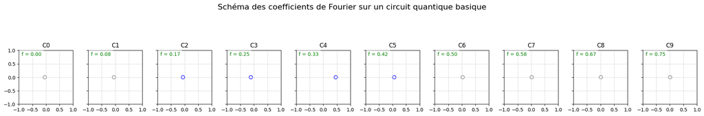

```python
num_layer = 2

gamma = 1

circuit_2 = "W(v,v,v)-S(x)-S(x)-W(v,v,v)"


Qm2 = quantum_model(circuit_2, gamma)


display_coefficients_fourier(Qm2, 10, np.linspace(-6, 6, 1024), "Schéma des coefficients de Fourier sur un circuit quantique basique")
```

Directement, le modèle devient plus expressif dans l'approximation des fonctions. La capacité d'entrées des X augmente considérablement l'expressivité du modèle.

Mais le fait d'être plus expressif ne garantit pas que l'on peut être plus performant dans l'approximation de fonction.

Essayons sur cette fonction dont vous pouvez remarquer l'implémentation :

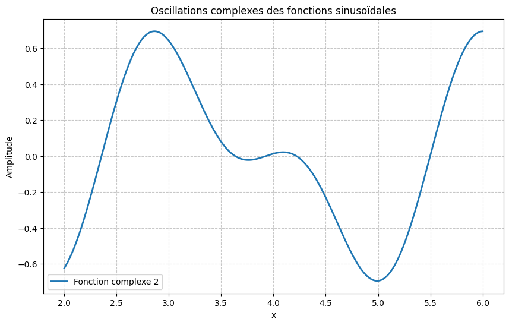

```python
import numpy as np
import matplotlib.pyplot as plt

def sinusoidale_complexe(x):
    return  0.5*np.cos(2 * x) - 0.3 * np.sin(4 * x)

# Génération des valeurs de x
x_values = np.linspace(2, 6, 500)
y = sinusoidale_complexe(x_values)

# Affichage avec Matplotlib
plt.figure(figsize=(10, 6))
plt.plot(x_values, y, label="Fonction complexe 2", linewidth=2)
plt.xlabel("x")
plt.ylabel("Amplitude")
plt.title("Oscillations complexes des fonctions sinusoïdales")
plt.legend()
plt.grid(True, linestyle="--", alpha=0.7)
plt.show()
```

Maintenant, testons l'approximation des modèles précédents pour justifier la cohérence de nos résultats.

Commençons avec le circuit 0 sans ajouts :

```
--- Circuit ---
|0⟩—[W(0j, 0j, 0j)]—[S(0j)]—[W(0j, 0j, 0j)]—> M

Step 1: Loss = 0.037177
Step 2: Loss = 0.096643
Step 3: Loss = 0.078426
Step 4: Loss = 0.046997
Step 5: Loss = 0.044001
Step 6: Loss = 0.061798
Step 7: Loss = 0.030270
Step 8: Loss = 0.072376
Step 9: Loss = 0.061820
Step 10: Loss = 0.038474
Step 11: Loss = 0.044907
Step 12: Loss = 0.024073
Step 13: Loss = 0.026864
Step 14: Loss = 0.033110
Step 15: Loss = 0.035016
Step 16: Loss = 0.027797
Step 17: Loss = 0.023721
Step 18: Loss = 0.027359
Step 19: Loss = 0.020264
Step 20: Loss = 0.031846
Step 21: Loss = 0.019285
Step 22: Loss = 0.043254
Step 23: Loss = 0.032904
Step 24: Loss = 0.033014
Step 25: Loss = 0.024329
Step 26: Loss = 0.024757
Step 27: Loss = 0.024901
Step 28: Loss = 0.027764
Step 29: Loss = 0.025377
Step 30: Loss = 0.025933
Step 31: Loss = 0.025642
Step 32: Loss = 0.021913
Step 33: Loss = 0.018223
Step 34: Loss = 0.019118
Step 35: Loss = 0.025385
Step 36: Loss = 0.018872
Step 37: Loss = 0.025021
```

[output cut: 48 more lines]

```
Step 86: Loss = 0.029539
Step 87: Loss = 0.026668
Step 88: Loss = 0.025553
Step 89: Loss = 0.026347
Step 90: Loss = 0.020555
Step 91: Loss = 0.026892
Step 92: Loss = 0.020571
Step 93: Loss = 0.024993
Step 94: Loss = 0.020245
Step 95: Loss = 0.020929
Step 96: Loss = 0.021366
Step 97: Loss = 0.022569
Step 98: Loss = 0.020940
Step 99: Loss = 0.025589
Step 100: Loss = 0.025412
```

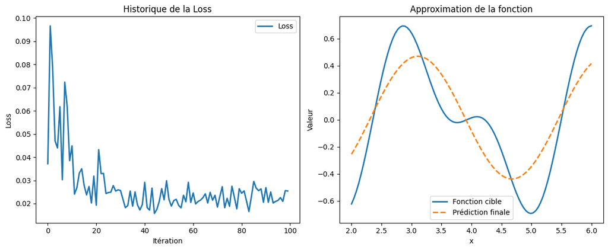

```python
approximate(
        sinusoidale_complexe,
        circuit_0,
        linespace = (2,6),
        number_points = 100,
        gamma = 2,
        steps = 100,
        learning_rate = 0.3,
        plot = False
    )
```

Notre circuit initial ne permet pas d'approximer la fonction sinusoïdale complexe. Cette approximation nous donne un point de départ pour comparer les différents circuits.

Passons à l'approximation du circuit 1 :

```
--- Circuit ---
|0⟩—[W(0j, 0j, 0j)]—[W(0j, 0j, 0j)]—[S(0j)]—[W(0j, 0j, 0j)]—> M

Step 1: Loss = 0.055956
Step 2: Loss = 0.043355
Step 3: Loss = 0.064441
Step 4: Loss = 0.046432
Step 5: Loss = 0.068305
Step 6: Loss = 0.046026
Step 7: Loss = 0.051214
Step 8: Loss = 0.031075
Step 9: Loss = 0.024927
Step 10: Loss = 0.030237
Step 11: Loss = 0.040712
Step 12: Loss = 0.034520
Step 13: Loss = 0.021320
Step 14: Loss = 0.021622
Step 15: Loss = 0.024500
Step 16: Loss = 0.040651
Step 17: Loss = 0.030406
Step 18: Loss = 0.032513
Step 19: Loss = 0.025762
Step 20: Loss = 0.032647
Step 21: Loss = 0.029431
Step 22: Loss = 0.022102
Step 23: Loss = 0.024278
Step 24: Loss = 0.028846
Step 25: Loss = 0.026575
Step 26: Loss = 0.023645
Step 27: Loss = 0.028504
Step 28: Loss = 0.026562
Step 29: Loss = 0.026282
Step 30: Loss = 0.028034
Step 31: Loss = 0.027181
Step 32: Loss = 0.023999
Step 33: Loss = 0.034511
Step 34: Loss = 0.018152
Step 35: Loss = 0.019918
Step 36: Loss = 0.020950
Step 37: Loss = 0.023332
```

[output cut: 48 more lines]

```
Step 86: Loss = 0.028929
Step 87: Loss = 0.025582
Step 88: Loss = 0.019304
Step 89: Loss = 0.024731
Step 90: Loss = 0.027371
Step 91: Loss = 0.024200
Step 92: Loss = 0.021470
Step 93: Loss = 0.023808
Step 94: Loss = 0.020725
Step 95: Loss = 0.023963
Step 96: Loss = 0.023650
Step 97: Loss = 0.016374
Step 98: Loss = 0.019782
Step 99: Loss = 0.025722
Step 100: Loss = 0.028786
```

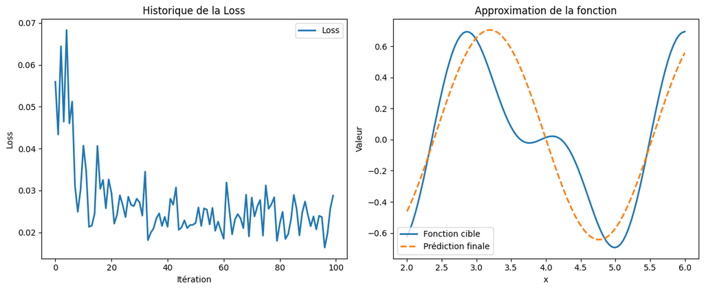

```python
approximate(
        sinusoidale_complexe,
        circuit_1,
        linespace = (2,6),
        number_points = 100,
        gamma = 2,
        steps = 100,
        learning_rate = 0.3,
        plot = False
    )
```

Comme on a pu le prévoir avec notre analyse des coefficients de Fourier quantique, le fait d’augmenter les poids n’améliore pas la capacité à approximer la fonction, celle-ci reste constante.

```
--- Circuit ---
|0⟩—[W(0j, 0j, 0j)]—[S(0j)]—[S(0j)]—[W(0j, 0j, 0j)]—> M

Step 1: Loss = 0.296218
Step 2: Loss = 0.162582
Step 3: Loss = 0.103134
Step 4: Loss = 0.177933
Step 5: Loss = 0.121708
Step 6: Loss = 0.106040
Step 7: Loss = 0.094704
Step 8: Loss = 0.063889
Step 9: Loss = 0.061362
Step 10: Loss = 0.066461
Step 11: Loss = 0.076243
Step 12: Loss = 0.124221
Step 13: Loss = 0.098411
Step 14: Loss = 0.073462
Step 15: Loss = 0.085124
Step 16: Loss = 0.069043
Step 17: Loss = 0.066106
Step 18: Loss = 0.091246
Step 19: Loss = 0.094274
Step 20: Loss = 0.095864
Step 21: Loss = 0.071930
Step 22: Loss = 0.056406
Step 23: Loss = 0.025734
Step 24: Loss = 0.055376
Step 25: Loss = 0.069847
Step 26: Loss = 0.078729
Step 27: Loss = 0.042405
Step 28: Loss = 0.065943
Step 29: Loss = 0.068462
Step 30: Loss = 0.045926
Step 31: Loss = 0.084791
Step 32: Loss = 0.040876
Step 33: Loss = 0.050884
Step 34: Loss = 0.065525
Step 35: Loss = 0.053133
Step 36: Loss = 0.078290
Step 37: Loss = 0.085127
```

[output cut: 48 more lines]

```
Step 86: Loss = 0.049244
Step 87: Loss = 0.051543
Step 88: Loss = 0.060884
Step 89: Loss = 0.053129
Step 90: Loss = 0.054708
Step 91: Loss = 0.045753
Step 92: Loss = 0.047352
Step 93: Loss = 0.061546
Step 94: Loss = 0.058868
Step 95: Loss = 0.058900
Step 96: Loss = 0.056189
Step 97: Loss = 0.037828
Step 98: Loss = 0.048609
Step 99: Loss = 0.063130
Step 100: Loss = 0.063184
```

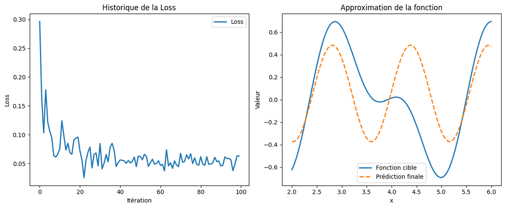

```python
approximate(
        sinusoidale_complexe,
        circuit_2,
        linespace = (2,6),
        number_points = 100,
        gamma = 2,
        steps = 100,
        learning_rate = 0.3,
        plot = False
    )
```

```
--- Circuit ---
|0⟩—[W(0j, 0j, 0j)]—[S(0j)]—[W(0j, 0j, 0j)]—[S(0j)]—[W(0j, 0j, 0j)]—> M

Step 1: Loss = 0.267504
Step 2: Loss = 0.211109
Step 3: Loss = 0.062501
Step 4: Loss = 0.097822
Step 5: Loss = 0.021454
Step 6: Loss = 0.031067
Step 7: Loss = 0.082307
Step 8: Loss = 0.071697
Step 9: Loss = 0.067715
Step 10: Loss = 0.070939
Step 11: Loss = 0.112802
Step 12: Loss = 0.077902
Step 13: Loss = 0.057240
Step 14: Loss = 0.024788
Step 15: Loss = 0.034311
Step 16: Loss = 0.050273
Step 17: Loss = 0.041363
Step 18: Loss = 0.038451
Step 19: Loss = 0.025103
Step 20: Loss = 0.032150
Step 21: Loss = 0.035301
Step 22: Loss = 0.017794
Step 23: Loss = 0.009297
Step 24: Loss = 0.011207
Step 25: Loss = 0.019537
Step 26: Loss = 0.018488
Step 27: Loss = 0.010787
Step 28: Loss = 0.008781
Step 29: Loss = 0.003836
Step 30: Loss = 0.008871
Step 31: Loss = 0.008985
Step 32: Loss = 0.005488
Step 33: Loss = 0.007982
Step 34: Loss = 0.007489
Step 35: Loss = 0.010345
Step 36: Loss = 0.006713
Step 37: Loss = 0.001983
```

[output cut: 48 more lines]

```
Step 86: Loss = 0.000030
Step 87: Loss = 0.000055
Step 88: Loss = 0.000048
Step 89: Loss = 0.000057
Step 90: Loss = 0.000042
Step 91: Loss = 0.000046
Step 92: Loss = 0.000019
Step 93: Loss = 0.000044
Step 94: Loss = 0.000048
Step 95: Loss = 0.000037
Step 96: Loss = 0.000011
Step 97: Loss = 0.000012
Step 98: Loss = 0.000019
Step 99: Loss = 0.000014
Step 100: Loss = 0.000027
```

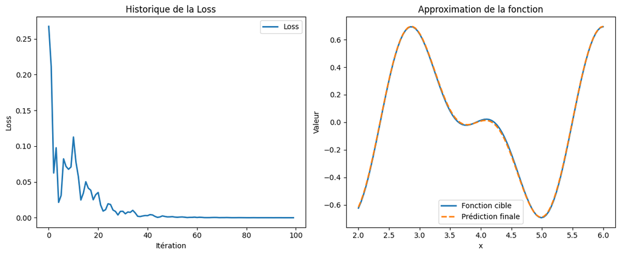

```python
circuit = "W(v,v,v)-S(x)-W(v,v,v)-S(x)-W(v,v,v)"

approximate(
        sinusoidale_complexe,
        circuit,
        linespace = (2,6),
        number_points = 100,
        gamma = 2,
        steps = 100,
        learning_rate = 0.3,
        plot = False
    )
```

La fonction est correctement approximée. Les portes d’encodage et de contrôle des poids forment un tout : elles sont complémentaires, l’une ne va pas sans l’autre.

# La limite de l'expréssivité quantique

Nous venons de voir que l’expressivité d’un modèle quantique est limitée par son nombre de portes qui encodent les features X.

**Mais jusqu’où cette expressivité est-elle limitée ?**

On suppose une liste $\lambda$ de taille $d$ dans le circuit quantique

$$ \lambda_1,\;\lambda_2,\;\dots,\;\lambda_d. $$

Pour chacune de ces valeurs propres, on va trouver des triplets de poids corrects $\Theta$ de cette manière qui correspondent au nombre de layers $L$ :
$$ (\theta_1,\theta_2,\dots,\theta_L)\quad\text{où}\quad \theta_t\in\{1,\dots,d\}. $$

On formalise la somme de tous ces composants $\theta$ :

$$ s_{\theta_1,\dots,\theta_L} \;=\;\sum_{t=1}^L \lambda_{\theta_t}. $$

$\Sigma = \{\,s_{\theta_1,\dots,\theta_L}\mid \theta_t\in\{1,\dots,d\}\}$.

Chaque choix de ($\theta_1$,…,$\theta_L$) correspond à une seule somme possible, et comme il y a $d^L$ choix possibles,

on obtient $$ \bigl|\Sigma\bigr|\;\le\;d^L. $$

Les fréquences sont les **différences** entre deux valeurs du spectre du modèle :
$$ \Omega \;=\;\bigl\{\,\omega = x - y \;\bigm|\; x,y\in \Sigma \bigr\}. $$

$$ \bigl|\Omega\bigr|\;\le\;|\Sigma|\times|\Sigma| \;\le\;d^L\times d^L \;=\;d^{2L}. $$

On fixe $K$, l'expressivité maximale d'un système quantique :

$$ K = |\Sigma|\times|\Sigma| $$

Ainsi

$$ K \;\le\;d^{2L} $$

On divise par 2 pour ne pas compter la fréquence homologue dans le calcul des deux listes de valeurs :

$$ K \;\le\;\frac{d^{2L}}{2} $$

La fréquence $0$ est exclue :

$$ K \;\le\;\frac{d^{2L}}{2}-1 $$

Maintenant, nous avons comment un modèle devient expressif et convergent, et la limite de cette convergence intrinsèquement liée au circuit qui le compose.